# More about visualization

## Plotting styles

The library matplotlib has multiple styles we can choose from. By default, matplotlib uses the style 'default'. However, you can choose your plotting style from nearly 30 different styles. See an array containing style names by running plt.style.available (note that the style 'default' is not included, as these are all the alternative styles that you can use).

Each style has a different unique default colours, line style and colours, background format and colours, etc. You can review different matplotlib styles at [Style sheets reference — Matplotlib 3.5.3 documentation](https://matplotlib.org/stable/gallery/style_sheets/style_sheets_reference.html).

To choose any of the other styles, simply run

- `plt.style.use('name-of-style')`

This will use the selected style when creating plots in your active session. Your style resets to 'default' when you start a new file (session).

## Making subplots

Let's re-create the bar charts for the Olympic Games medal count example.

First, load the dataset for the 2012 and 2016 Olympic games.

```python
import pandas as pd
medals_2012 = pd.read_csv("Data/Olympic_medals_2012.csv")
medals_2016 = pd.read_csv("Data/Olympic_medals_2016.csv")
```

Plot the 2012 Games.

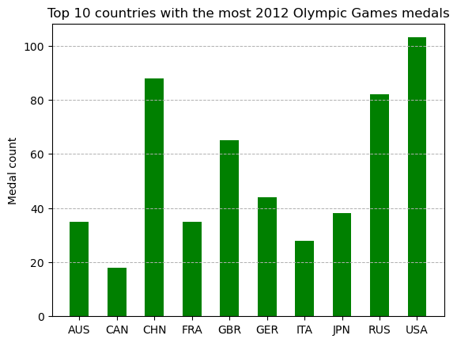

```python
import matplotlib.pyplot as plt

plt.bar(medals_2012['NOC'],medals_2012['Medal'],width=0.5, color='green')
plt.ylabel('Medal count')
plt.title('Top 10 countries with the most 2012 Olympic Games medals')
plt.grid(linestyle='--',linewidth=0.7,axis='y')
plt.show()
```

Plot the 2016 games.

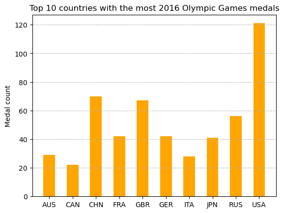

```python
plt.bar(medals_2016['NOC'],medals_2016['Medal'],width=0.5, color='orange')
plt.ylabel('Medal count')
plt.title('Top 10 countries with the most 2016 Olympic Games medals')
plt.grid(linestyle='--',linewidth=0.7,axis='y')
plt.show()
```

Sometimes we may want to include multiple plots in one figure.

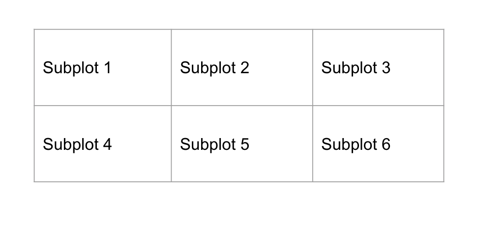

The `plt.subplot()` function combines several plots into one figure, and has three arguments, `nrows`, `ncols`, and `index`.

The argument of `plt.subplot(nrows, ncols, index)` includes integers, which determines the layout of the subplots.

- `nrows` indicates the number of rows.
- `ncols` indicates the number columns
- `index` indicates which spot is being used by the current plot.
- The comma between the three input arguments are often ommitted

**Note** that the commas between the arguments are often ommitted. For example:

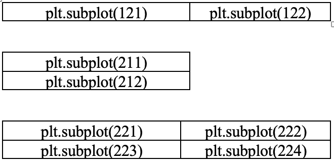

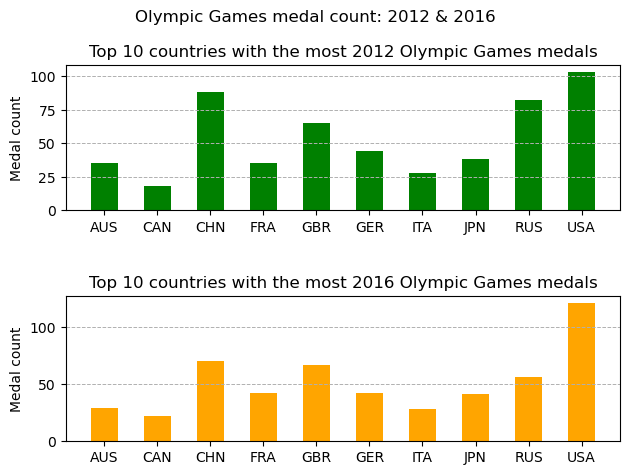

```python
plt.subplot(2,1,1)

plt.suptitle('Olympic Games medal count: 2012 & 2016')

plt.bar(medals_2012['NOC'],medals_2012['Medal'],width=0.5, color='green')
plt.ylabel('Medal count')
plt.title('Top 10 countries with the most 2012 Olympic Games medals')
plt.grid(linestyle='--',linewidth=0.7,axis='y')

plt.subplot(2,1,2)

plt.bar(medals_2016['NOC'],medals_2016['Medal'],width=0.5, color='orange')
plt.ylabel('Medal count')
plt.title('Top 10 countries with the most 2016 Olympic Games medals')
plt.grid(linestyle='--',linewidth=0.7,axis='y')

plt.tight_layout(h_pad = 3)
plt.show()
```

## Making animations

To make an animation, we need to create a series of frames.

- Each frame is a figure
- As we move to the next frame, a different figure will be plotted

Let's make an animation of horizontal "racing" bar charts of the Olympic medal counts by countries.

We first create a list of years and a list of DataFrames.

- Each DataFrame will lead to a frame of the animation

```python
years_list =[2012,2016]
medals_list = [medals_2012,medals_2016]
```

Now generate any plot.

Also,

- Use the magic command `%matplotlib notebook` to allow interactions/animations
- Use the function `plt.gcf()` to get the "figure" object of the plot

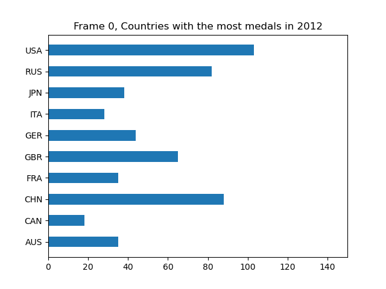

```python
%matplotlib notebook

plt.plot()
fig = plt.gcf()
```

We will now define the `update()` function

- The required argument is `frame`, which will start from 0
- We need to first clear the figure for each new frame, using `plt.cla()`
- Then add the new plot
- It is often useful to using the f-string to describe a frame

```python
def update(frame):
    plt.cla()  # Clear the current axes to redraw the chart

    medals = medals_list[frame]

    plt.barh(medals['NOC'],medals['Medal'],height=0.5)
    plt.xlim(0,150)
    plt.title(f"Frame {frame}, Countries with the most medals in {years_list[frame]}")
```

Finally, we can create the animation. To do that need to import the function `FuncAnimation()`

```python
from matplotlib.animation import FuncAnimation

medals_ani = FuncAnimation(fig, update, frames=2, interval=500)

plt.show()
```

```
MovieWriter ffmpeg unavailable; using Pillow instead.
```

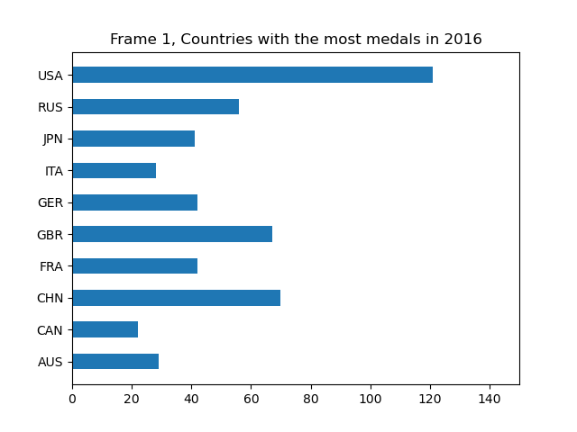

```python
medals_ani.save("1.gif")
```